# JHU COVID-19 data

Matt Brauer

April 06, 2020

# Contents

Latest version: Data update; dropped exponential fits (for now)

# 1 Background

This page contains plots of unprocessed data from Johns Hopkins University Center for Systems Science and Engineering (JHU CSSE). Since early January the CSSE has built and hosted a near real-time tracker of corona virus cases, with a [public visual dashboard](https://www.arcgis.com/apps/opsdashboard/index.html#/bda7594740fd40299423467b48e9ecf6).

(Also see relevant Lancet paper here: An interactive web-based dashboard to track COVID-19 in real time.)

Reported numbers of confirmed cases, deaths and recoveries are available in [their github repo](https://github.com/CSSEGISandData/COVID-19), which is the source for these plots.

Some cautions:

- The definition and number of “confirmed cases” is highly dependent on locale, availability and use of testing. It is a crude proxy and lagging indicator of the progress of the pandemic.
- These numbers are those reported by local authorities, and should be presumed to be inaccurate on that account.
- Reported numbers are absolute cumulative, not rates. They have not been scaled to population size.
- Dates are dates reported, not necessarily date of observation.

# 2 Some (more sophisticated and useful) tracking resources

- [UW Virology COVID-19 Dashboard](http://depts.washington.edu/labmed/covid19/)
- [Kinsa US Health Weather Map](https://healthweather.us/): real-time tracking of atypical fever frequencies
- [Epidemic modeling](http://gabgoh.github.io/COVID/index.html)
- [NEJM Coronavirus papers](https://www.nejm.org/coronavirus?cid=DM88311&bid=165352681)
- [The COVID Tracking Project](https://covidtracking.com/)
- [Our World in Data](https://ourworldindata.org/coronavirus)
- [JHU news releases](https://releases.jhu.edu/)
- [SF Chronicle California case tracker](https://projects.sfchronicle.com/2020/coronavirus-map/)
- [Real-time tracking of pathogen evolution](https://nextstrain.org/)
- [91-divoc](https://91-divoc.com)
- [COVID-19 health data](https://covid19.healthdata.org/)

# 3 Other news and information links

- [The Atlantic Covid-19 coverage](https://www.theatlantic.com/category/what-you-need-know-coronavirus/)
- [Home testing](https://www.ninetylawn.com/at-home-coronavirus-testing/)

# 4 Updates and notes

JHU appears to update their data daily at around 4pm PDT. I usually re-run the script sometime after that. At other times I’m fiddling with changing layouts and refactoring code, and updates usually reflect that.

Currently, plots are aligned by setting the local day 0 as the date at which a given country/locality crosses 10% of the maximum cases, deaths, etc. in a comparison.

To do: automate the estimation of maximum exponential parameter for various curves. Currently this is done by manually setting a date range over which the fit is done.

I’ll be happy to take requests for specific plots. Feel free to open an issue on the [project GitHub page](https://github.com/MattBrauer/covid19). Also, take, use and propagate any code or data you find there if you find it useful.

# 5 Progression of cases compared between countries

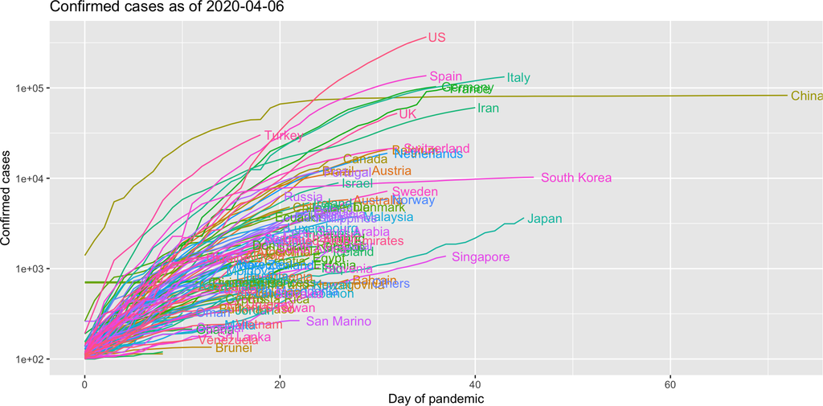

Figure 1: Progression of cases between countries  
Day 0 for each country is the first day for which there is data. In some cases (e.g., China, Japan) the pandemic was well underway before data were recorded by JHU.

# 6 Comparison of US to selected other countries

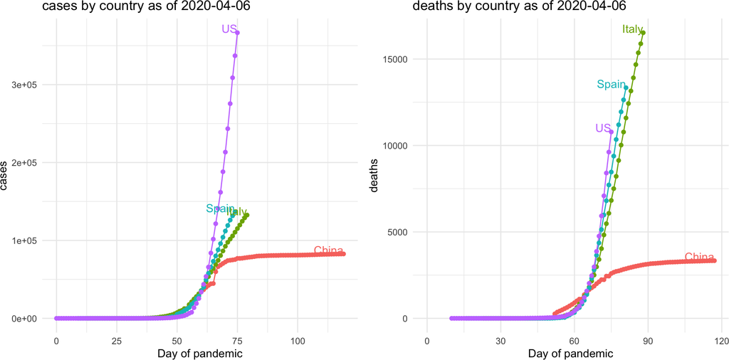

Figure 2: Pandemic trajectories of several countries  
Day of pandemic is an adjustment to allow for different local pandemic start dates.

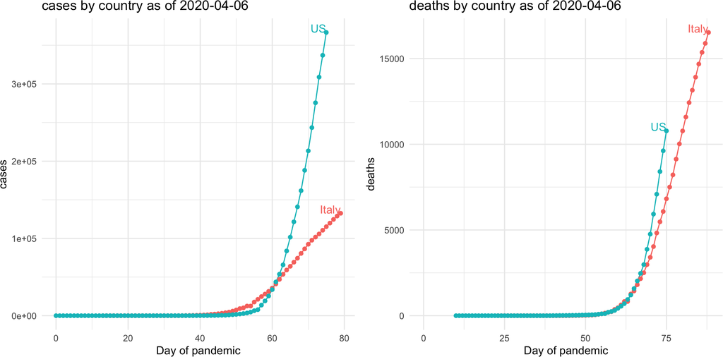

Figure 3: Comparing US to Italy  
Day of pandemic is an adjustment to allow for different local pandemic start dates.

# 7 Confirmed cases and deaths by US state

Cumulative number of confirmed cases aggregated across all regions within state.

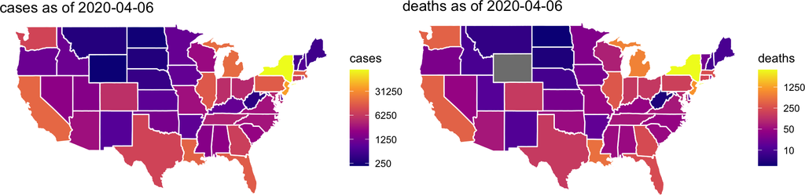

Figure 4: Cases and deaths by state

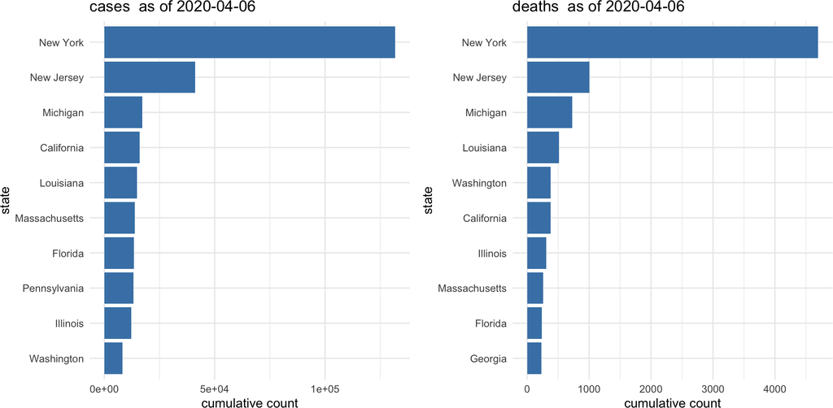

Figure 5: Cases and deaths by state  
Ten most affected states shown.

# 8 Confirmed cases and deaths by California county

Cumulative number of confirmed cases aggregated across all regions within state.

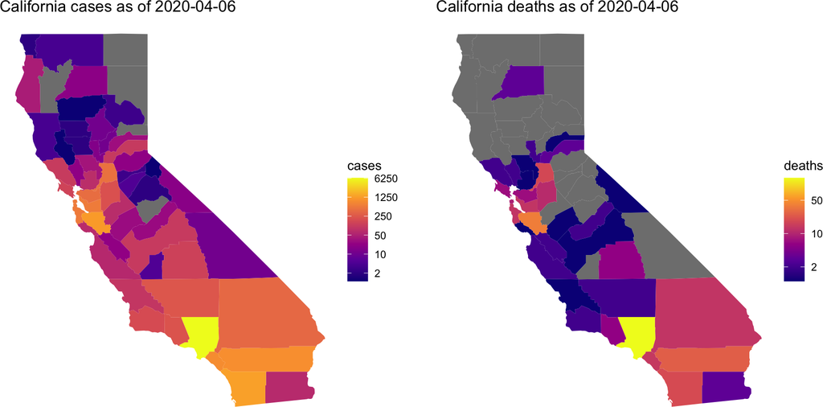

Figure 6: Cases and deaths within California

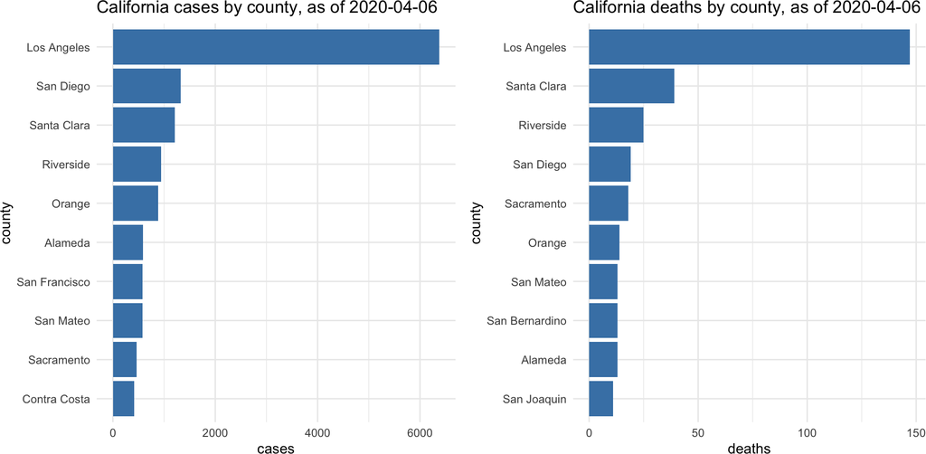

Figure 7: Cases and deaths within California

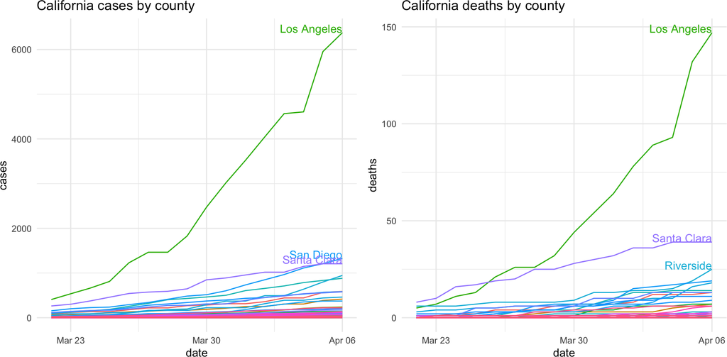

Figure 8: Cases and deaths within California